# 250411_UGrepeat

Irika Sinha

2025-04-11

## Purpose

The purpose of this script is to determine the location of UG repeats near cryptic exons

## Packages

```r
CRANpackages <- c("tidyverse", "XML","ggplot2", "ggpubr", "ggstats","BiocManager","viridis", "gghighlight")
biocPackages <- c("Biostrings","biomaRt")

for(i in CRANpackages){
  if(!(i %in% rownames(installed.packages()))){
    install.packages(pkgs = i)
  }
  library(package = i, character.only = T, quietly = T)
  rm(i)
}
```

```
## Bioconductor version '3.20' is out-of-date; the current release version '3.21'
##   is available with R version '4.5'; see https://bioconductor.org/install
```

```r
for(i in biocPackages){
  if(!(i %in% rownames(installed.packages()))){
    BiocManager::install(pkgs = i, ask = F)
  }
  library(package = i, character.only = T, quietly = T)
  rm(i)
}
rm(CRANpackages,biocPackages)
```

## Method of UG repeat calculation

Source: McClory SP, Lynch KW, Ling JP. HnRNP L represses cryptic exons. RNA. 2018 Jun;24(6):761-768. doi: 10.1261/rna.065508.117. Epub 2018 Mar 26. PMID: 29581412; PMCID: PMC5959245.

As per text: “Calculation of repeat frequency around hnRNP L-repressed cryptic exons in Figure 2B was done by

1. Masking all “CA” and “AC” as “YY”;
2. replacing all “A,” “C,” “T,” “G” as “N”;
3. identifying all pentamer and longer repeat sequences allowing for a single N insertion (i.e., “YYYYY,” “YYYYYY,” “YYYYYYY,” “YNYYYY,” “YYNYYY,” “YYYNYY,” “YYYYNY,” …);
4. assigning the “Y”s in sequences from step 3 a value of 1 and all other sequences a value of 0;
5. aligning all sequences to the 3′SS and 5′SS and calculating the repeat frequency for each base pair position (i.e., sum vertically and divide by the total number of sequences).

Repeat frequencies for UG repeats (TDP-43) and CU repeats (PTBP1/PTBP2) were derived in a similar fashion.”

Default is for motif = “TG”

```r
dinucRepeatBinary <- function(testseq, motif="TG"){
  ## Catch NAs
if(is.na(testseq)){
  return(NA)
}

testseq <- toupper(testseq)
pattern1 = motif
pattern2 = Biostrings::reverse(motif)

  ## Step 1: Masking all “UG” and “GU” as “YY” or given pattern
testseq_mask1 <- str_replace_all(string = testseq, pattern = pattern1, replacement = "YY")
testseq_mask2 <- str_replace_all(string = testseq, pattern = pattern2, replacement = "YY")

testseq_mask = c()

## Step 2: Replacing all non-Y nucleotides as “N”;
# Combining masks too
for(i in 1:str_length(testseq)){
  if(str_split_i(testseq_mask1,"",i) == "Y" | str_split_i(testseq_mask2,"",i) == "Y"){
    testseq_mask[i] = "Y"
  } else{testseq_mask[i] = "N"}
  rm(i)
}

testseq_mask <- str_flatten(testseq_mask)
rm(testseq_mask1, testseq_mask2)

## Step3: Identifying all pentamer and longer repeat sequences allowing for a single N insertion (i.e., “YYYYY,” “YYYYYY,” “YYYYYYY,” “YNYYYY,” “YYNYYY,” “YYYNYY,” “YYYYNY,” …);
testseq_mask_list <- unlist(str_split(testseq_mask,""))

testseq_num <- c()
counter = 0

for(i in 1:length(testseq_mask_list)){
  currentVal = testseq_mask_list[i]
  pastVal = testseq_mask_list[i-1]
  nextVal = testseq_mask_list[i+1]

  if(currentVal == "Y"){
    counter = counter + 1

    # Deal with right edge
    if(i == length(testseq_mask_list)){
      if(counter >= 5){
        testseq_num <- append(testseq_num, c(rep(1,counter)))
      } else{
        testseq_num <- append(testseq_num, c(rep(0,counter)))
      }
      rm(counter)
    }

# Deal with various locations of "N"
  } else if(i == 1){
    # Deal with left edge
    testseq_num <- append(testseq_num, 0)
    counter=0
  } else if(i < length(testseq_mask_list)){
    # Deal with embedded N
    if(pastVal == "Y" & nextVal == "Y"){
      counter = counter + 1
    } else{
    # Deal with N not included in a repeat
      if(counter >= 5){
        testseq_num <- append(testseq_num, c(rep(1,counter),0))
      } else{
        testseq_num <- append(testseq_num, c(rep(0,counter),0))
      }
      counter = 0
    }
  } else if(i == length(testseq_mask_list)){
    if(counter >= 5){
      testseq_num <- append(testseq_num, c(rep(1,counter),0))
    } else{
      testseq_num <- append(testseq_num, c(rep(0,counter),0))
    }

    rm(counter)
  }
  rm(i, currentVal, pastVal, nextVal)
}
return(str_flatten(testseq_num))
}
```

```r
cryptic_df = read_delim("output_tables/250506_CrypticCoordinates_Fill.csv")
cryptic_df_coord <- cryptic_df[,c(1:4,6,18,19)] %>% mutate(leftRegion = NA,
                                                         rightRegion = NA)

# Determine

for(i in 1:nrow(cryptic_df_coord)){
  if(!is.na(cryptic_df_coord$LeftJunction[i])){
    chr = str_split_i(cryptic_df_coord$LeftJunction[i],":",1)
    leftSplice = as.numeric(str_split_i(cryptic_df_coord$LeftJunction[i],"-",2))+50
    cryptic_df_coord$leftRegion[i] = paste0(chr,":",leftSplice-650,",",leftSplice)
    rm(leftSplice)
  }

  if(!is.na(cryptic_df_coord$RightJunction[i])){
    chr = str_split_i(cryptic_df_coord$RightJunction[i],":",1)
    rightSplice = as.numeric(str_split_i(str_split_i(cryptic_df_coord$RightJunction[i],":",2),"-",1))-50
    cryptic_df_coord$rightRegion[i] = paste0(chr,":",rightSplice,",",rightSplice+650)
    rm(rightSplice)
  }

  rm(i)
}

manualFixL = which(str_split_i(cryptic_df_coord$leftRegion,":",2) == "NA,NA")
manualFixR = which(str_split_i(cryptic_df_coord$rightRegion,":",2) == "NA,NA") # No problems

for(i in 1:length(manualFixL)){
  CE = cryptic_df_coord$`Cryptic Exon Location\n  (hg38)`[manualFixL[i]]
  chr = str_split_i(CE,":",1)
  leftSplice = as.numeric(str_split_i(CE,"-",2))+49
  cryptic_df_coord$leftRegion[manualFixL[i]] = paste0(chr,":",leftSplice-650,",",leftSplice)
  rm(CE,i, leftSplice, chr)
}

cryptic_df_coord <- cryptic_df_coord %>% mutate(urlL = paste0("http://genome.ucsc.edu/cgi-bin/das/hg38/dna?segment=",leftRegion),
                                                urlR = paste0("http://genome.ucsc.edu/cgi-bin/das/hg38/dna?segment=",rightRegion))

cryptic_df_coord$urlL[which(is.na(cryptic_df_coord$LeftJunction))] = NA
cryptic_df_coord$urlR[which(is.na(cryptic_df_coord$RightJunction))] = NA



# write_delim(cryptic_df_coord[,9], "output_tables/250411_cryptic_df_coord_left.txt", col_names = F)
# write_delim(cryptic_df_coord[,10], "output_tables/250411_cryptic_df_coord_right.txt", col_names = F)
```

## Download seq from UCSC

BASH ISN’T WORKING

```bash
cd output_tables
> 250411_cryptic_df_coord_left_fill.txt
> 250411_cryptic_df_coord_right_fill.txt

while read urlLine; do
  curl -s $urlLine  | xmllint --xpath '/DASDNA/SEQUENCE/DNA/text()' - | tr -d '\n' >> 250411_cryptic_df_coord_left_fill.txt
  echo "\n" >> 250411_cryptic_df_coord_left_fill.txt
done < 250411_cryptic_df_coord_left.txt

while read urlLine; do
  curl -s $urlLine  | xmllint --xpath '/DASDNA/SEQUENCE/DNA/text()' - | tr -d '\n' >> 250411_cryptic_df_coord_right_fill.txt
  echo "\n" >> 250411_cryptic_df_coord_right_fill.txt
done < 250411_cryptic_df_coord_right.txt
```

Download XML files from UCSC genome browser to get relevant sequences

```r
cryptic_df_coord <- cryptic_df_coord %>% mutate(seqL = NA, seqR = NA)

for(i in 1:nrow(cryptic_df_coord)){
  for(j in c("urlL","urlR")){
    if(!is.na(cryptic_df_coord[[j]][i])){
      xmlF <- read.csv(cryptic_df_coord[[j]][i])
      xmlF <- xmlF[5:(nrow(xmlF)-3),]

      seq <- str_flatten(xmlF)

      if(j == "urlL"){
        cryptic_df_coord$seqL[i] = seq
      } else{cryptic_df_coord$seqR[i] = seq}
    }
  }
  rm(j,i,xmlF,seq)
}

# write.csv(cryptic_df_coord,"output_tables/250506_cryptic_df_coord_seqFill.csv")
```

## Determine correct strand

```r
cryptic_df_coord <- read_delim("output_tables/250506_cryptic_df_coord_seqFill.csv")[-1]
```

```
## ──────────────────────────────────────────────────────── Delimiter: "," chr
## (13): Gene Symbol, CE Detail, Ensembl ID, ID #, Cryptic Exon Location ... dbl
## (1): ...1
```

```r
ensembl = useEnsembl(biomart="ensembl", dataset="hsapiens_gene_ensembl")
biomart_CE <- getBM(attributes=c("external_gene_name",'ensembl_gene_id','strand'),
                    filters = 'ensembl_gene_id', values = cryptic_df_coord$`Ensembl ID`, mart = ensembl)

cryptic_df_coord <- cryptic_df_coord %>% left_join(biomart_CE,join_by(`Ensembl ID` == "ensembl_gene_id"))

#Find blanks - none
which(!(cryptic_df_coord$strand %in% c(-1,1)))
```

```
## integer(0)
```

```r
# change sequences as needed

for(i in 1:nrow(cryptic_df_coord)){
  if(cryptic_df_coord$strand[i] == -1){
    if(!is.na(cryptic_df_coord$seqL[i])){
      seq <- DNAString(cryptic_df_coord$seqL[i])
      seq <- reverseComplement(seq)
      cryptic_df_coord$seqL[i] = as.character(unlist(seq))

      rm(seq)
    }

    if(!is.na(cryptic_df_coord$seqR[i])){
      seq <- DNAString(cryptic_df_coord$seqR[i])
      seq <- reverseComplement(seq)
      cryptic_df_coord$seqR[i] = as.character(unlist(seq))

      rm(seq)
    }
    seqLtoR = cryptic_df_coord$seqL[i]
    seqRtoL = cryptic_df_coord$seqR[i]

    cryptic_df_coord$seqL[i] = seqRtoL
    cryptic_df_coord$seqR[i] = seqLtoR
  }
  rm(i)
}


# write.csv(cryptic_df_coord,"output_tables/250506_cryptic_df_coord_seq_strand.csv")
```

## Use UGrepeat function

```r
cryptic_df_coord <- read_delim("output_tables/250506_cryptic_df_coord_seq_strand.csv")[-1]
```

```
## ──────────────────────────────────────────────────────── Delimiter: "," chr
## (14): Gene Symbol, CE Detail, Ensembl ID, ID #, Cryptic Exon Location ... dbl
## (2): ...1, strand
```

```r
cryptic_df_coord <- cryptic_df_coord %>% mutate(seqRepL_UG = NA, seqRepR_UG = NA)

cryptic_df_coord$seqRepL_UG <- unlist(lapply(toupper(cryptic_df_coord$seqL),dinucRepeatBinary))
cryptic_df_coord$seqRepR_UG <- unlist(lapply(toupper(cryptic_df_coord$seqR),dinucRepeatBinary))

# write.csv(cryptic_df_coord,"output_tables/250506_cryptic_df_coord_UGrepcalc.csv")
cryptic_df_coord <- read_delim("output_tables/250506_cryptic_df_coord_UGrepcalc.csv")[-1]
```

```
## ──────────────────────────────────────────────────────── Delimiter: "," chr
## (16): Gene Symbol, CE Detail, Ensembl ID, ID #, Cryptic Exon Location ... dbl
## (2): ...1, strand
```

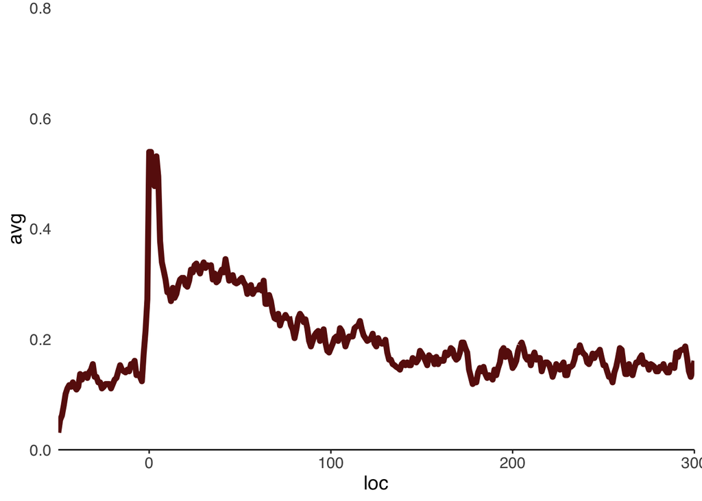

```r
mathUG_df_L <- data.frame("loc" = -600:50)
mathUG_df_R <- data.frame("loc" = -50:600)

for(i in 1:nrow(cryptic_df_coord)){
  if(!is.na(cryptic_df_coord$seqRepL_UG[i])){
    mathUG_df_L <- cbind(mathUG_df_L, as.numeric(unlist(str_split(cryptic_df_coord$seqRepL_UG[i],""))))
    colnames(mathUG_df_L)[ncol(mathUG_df_L)] = cryptic_df_coord$`ID #`[i]
  }

  if(!is.na(cryptic_df_coord$seqRepR_UG[i])){
    mathUG_df_R <- cbind(mathUG_df_R, as.numeric(unlist(str_split(cryptic_df_coord$seqRepR_UG[i],""))))
    colnames(mathUG_df_R)[ncol(mathUG_df_R)] = cryptic_df_coord$`ID #`[i]
  }
  rm(i)
}

mathUG_df_L$avg = apply(mathUG_df_L[,2:ncol(mathUG_df_L)],MARGIN=1,function(x) round(mean(x),3))
mathUG_df_R$avg = apply(mathUG_df_R[,2:ncol(mathUG_df_R)],MARGIN=1,function(x) round(mean(x),3))

# write.csv(mathUG_df_L, "output_tables/250506_cryptic_df_UG_freq_L.csv")
# write.csv(mathUG_df_R, "output_tables/250506_cryptic_df_UG_freq_R.csv")

ggplot(mathUG_df_R, aes(x=loc,y=avg))+
  geom_line(linewidth = 2,colour = "#69140E")+
  theme_classic()+
  scale_y_continuous(expand = c(0, 0),limits = c(0,0.8))+
  scale_x_continuous(expand=c(0,0),limits = c(-50,300))+
  theme(text = element_text(size = 14, family = "Helvetica", color="black"),
        axis.ticks.y = element_blank(),
        axis.line.y = element_blank())
```

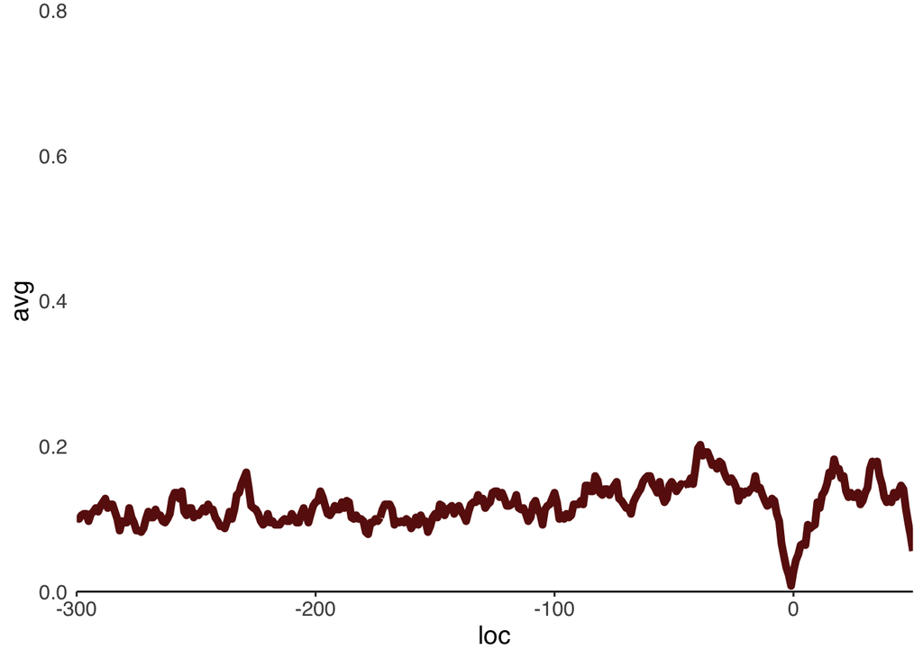

```r
ggplot(mathUG_df_L, aes(x=loc,y=avg))+geom_line(linewidth = 2,colour = "#69140E")+
  theme_classic()+
  scale_y_continuous(expand = c(0, 0),limits = c(0,0.8))+
  scale_x_continuous(expand=c(0,0),limits = c(-300,50))+
  theme(text = element_text(size = 14, family = "Helvetica", color="black"),
        axis.ticks.y = element_blank(),
        axis.line.y = element_blank())
```

## Check CA repeat

```r
cryptic_df_coord <- read_delim("output_tables/250506_cryptic_df_coord_UGrepcalc.csv")[-1]
```

```
## ──────────────────────────────────────────────────────── Delimiter: "," chr
## (16): Gene Symbol, CE Detail, Ensembl ID, ID #, Cryptic Exon Location ... dbl
## (2): ...1, strand
```

```r
cryptic_df_coord <- cryptic_df_coord %>% mutate(seqRepL_CA = NA, seqRepR_CA = NA)

cryptic_df_coord$seqRepL_CA <- unlist(lapply(cryptic_df_coord$seqL, function(x) dinucRepeatBinary(x, motif="CA")))
cryptic_df_coord$seqRepR_CA <- unlist(lapply(cryptic_df_coord$seqR, function(x) dinucRepeatBinary(x, motif="CA")))

# write.csv(cryptic_df_coord,"output_tables/250506_cryptic_df_coord_CArepcalc.csv")
cryptic_df_coord <- read_delim("output_tables/250506_cryptic_df_coord_CArepcalc.csv")[-1]
```

```
## ──────────────────────────────────────────────────────── Delimiter: "," chr
## (18): Gene Symbol, CE Detail, Ensembl ID, ID #, Cryptic Exon Location ... dbl
## (2): ...1, strand
```

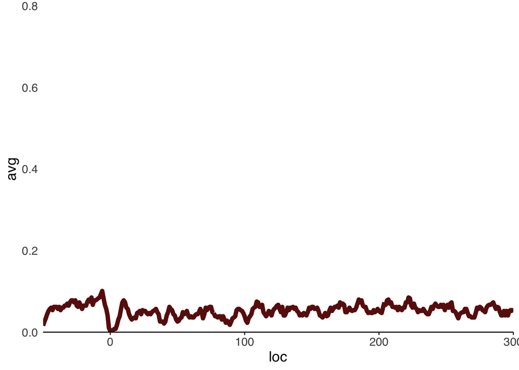

```r
mathCA_df_L <- data.frame("loc" = -600:50)
mathCA_df_R <- data.frame("loc" = -50:600)

for(i in 1:nrow(cryptic_df_coord)){
  if(!is.na(cryptic_df_coord$seqRepL_CA[i])){
    mathCA_df_L <- cbind(mathCA_df_L, as.numeric(unlist(str_split(cryptic_df_coord$seqRepL_CA[i],""))))
    colnames(mathCA_df_L)[ncol(mathCA_df_L)] = cryptic_df_coord$`ID #`[i]
  }

  if(!is.na(cryptic_df_coord$seqRepR_CA[i])){
    mathCA_df_R <- cbind(mathCA_df_R, as.numeric(unlist(str_split(cryptic_df_coord$seqRepR_CA[i],""))))
    colnames(mathCA_df_R)[ncol(mathCA_df_R)] = cryptic_df_coord$`ID #`[i]
  }
  rm(i)
}

mathCA_df_L$avg = apply(mathCA_df_L[,2:ncol(mathCA_df_L)],MARGIN=1,function(x) round(mean(x),3))
mathCA_df_R$avg = apply(mathCA_df_R[,2:ncol(mathCA_df_R)],MARGIN=1,function(x) round(mean(x),3))

# write.csv(mathCA_df_L, "output_tables/250506_cryptic_df_CA_freq_L.csv")
# write.csv(mathCA_df_R, "output_tables/250506_cryptic_df_CA_freq_R.csv")

ggplot(mathCA_df_R, aes(x=loc,y=avg))+
  geom_line(linewidth = 2,colour = "#69140E")+
  theme_classic()+
  scale_y_continuous(expand = c(0, 0),limits = c(0,0.8))+
  scale_x_continuous(expand=c(0,0),limits = c(-50,300))+
  theme(text = element_text(size = 14, family = "Helvetica", color="black"),
        axis.ticks.y = element_blank(),
        axis.line.y = element_blank())
```

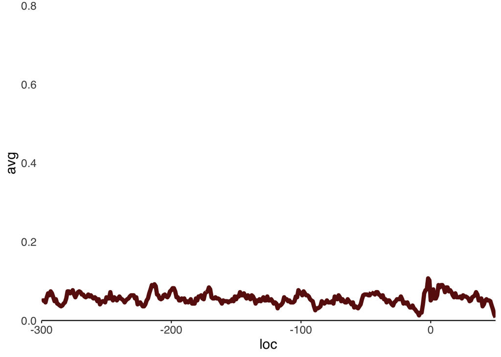

```r
ggplot(mathCA_df_L, aes(x=loc,y=avg))+geom_line(linewidth = 2,colour = "#69140E")+
  theme_classic()+
  scale_y_continuous(expand = c(0, 0),limits = c(0,0.8))+
  scale_x_continuous(expand=c(0,0),limits = c(-300,50))+
  theme(text = element_text(size = 14, family = "Helvetica", color="black"),
        axis.ticks.y = element_blank(),
        axis.line.y = element_blank())
```